# Trabajo Grupal R

Afrania Palomino

Diana Obregón

José Guimaray

Leonel Figueroa

```r
options(scipen = 999)
library(ggplot2)
library(sf)
library(readr)
library(stringr)
library(remotes)
library(magrittr)
library(dplyr)
library(mapsPERU)
library(readr)
library(naniar)
library(mapsPERU)
library(dplyr)
library(sf)
library(ggplot2)
library(scales)
```

# *Análisis espacial a nivel regional de los recursos transferidos del Gobierno Nacional a los Gobiernos Locales durante pandemia en el año 2020*

## Abstract:

El presente artículo muestra un análisis de diversas variables que describen la distribución de recursos y desarrollo del Proyecto Reactiva Perú 1 y 2, el cual se basó en la transferencia de recursos por parte del Ministerio de Vivienda, Construcción y Saneamiento (MVCS) a municipalidades locales del Perú con el objetivo de ejecutar obras de infraestructura. El análisis de las variables de distribución de recursos a nivel regional y provincial, población beneficiada y montos de inversión se logró a partir de su visualización en mapas y gráficos mediante el uso de los paquetes ggplot2 y mapsPERU que incluye el software estadístico R y su interfaz gráfica RStudio.

## Objetivo

Los gráficos generados en el presente artículo presentarán los recursos transferidos del Gobierno Nacional a los gobiernos locales a través del Ministerio de Vivienda, Construcción y Sanemamiento, durante el periodo 2020, lo que nos pueden dar una muestra del nivel de cobertura de los montos transferidos a nivel departamental y provincial por parte del gobierno central.

Asimismo, se podrá conocer la relación entre el monto transferido y el número de población beneficiaria por el proyecto de inversión pública.

## Metodología

La metodología se basa en un análisis descriptivo de la información descargada en la Plataforma Nacional de datos abiertos del gobierno del Perú.Asimismo se presenta mapas de visualización a nivel regional y departamental.

Los datos geoespaciales, conocidos como “shapefiles” contienen datos espaciales de representación vectorial que almacenan información de la ubicación de distintas entidades geográficas, la cual se puede representar con puntos, lineas o polígonos. En ese sentido, el paquete “ggplot2”es utilizado para la generación de mapas visualmente atractivos a partir de información geográfica almacenada en un shapefile, en el caso peruano estos estan delimitados a nivel departamental, provincial y distrital.

El uso de mapas es un medio utilizado para reportar estadísticas oficiales producidas por instituciones del gobierno central con el fin de hacerlas más digeribles para el lector. Ejemplo de ello es el documento producido por el INEI “Mapa de pobreza monetaria provincial y distrital 2018”, el cual contiene indicadores de pobreza[^1], desagregada geográficamente a nivel de provincial y distrital, la cual constituye por su naturaleza un importante insumo para la priorización y la implementación de políticas sociales en los distritos más vulnerables del país (INEI, 2018).

> 1. Data:

**PROYECTOS REACTIVA PERÚ 1 Y 2:** La base de datos utilizada corresponde a los Proyectos ejecutados por municipalidades distritales y provinciales como parte del Reactiva Perú 1 y 2, el cual fue llevado a cabo por el Ministerio de Vivienda, Construcción y Saneamiento (MVCS).

```r
link <- "https://raw.githubusercontent.com/Diane-12/BD_Pytoreactiva/main/pyto_reactica_12_original_vs2.csv"
bd_reactiva_pyto <- read.csv(link)
bd_reactiva_pyto <- bd_reactiva_pyto[-c(526), ]
# head(bd_reactiva_pyto,n=5) # Podemos usar esta función visiualizar los 05 primeros elementos de nuestra base de datos
# sapply(bd_reactiva_pyto, class) # Podemos usarla para conocer la clase de cada variable de nuestro base de datos
```

La base de datos muestra información de los Proyectos hasta junio del 2021 y se obtuvo del siguiente [enlace](https://www.datosabiertos.gob.pe/dataset/proyectos-reactiva-per%C3%BA.)

De esta base de datos se recogieron las siguientes variables:

*1. UBIGEO:* Código del distrito donde se ubica el proyecto.

*2. COD_REGION:* Código de la región donde se ubica el proyecto.

*3. COD_PROVINCIA:* Código de la provincia donde se ubica el proyecto.

*4. REGION:* Región donde se ubica el proyecto.

*5. PROVINCIA:* Provincia donde se ubica el proyecto.

*6. TOTALEMPLEOS:* Número de empleos generados con la ejecución del proyecto.

*7. POBLACIONBENEFICIARIA:* Número de población beneficiada con el proyecto.

*8. MONTODEINVERSIÓN:* Monto total de inversión del proyecto.

*9. MONTODETRANSFERENCIA2020:* Monto transferido al gobierno local en el periodo 2020.

*10. ESTADO:* Etapa en la que se encuentra el proyecto.

Adicionalmente, se utilizó una base de datos complementaria para obtener la población de los distritos presentes en la base de datos sobre Proyectos Reactiva Perú.

**POBLACION_2017:** La base de datos incluye información respecto a la población a nivel distrital teniendo como fuente el Censo Nacional 2017 y obteniendo la base de datos del siguiente [enlace](https://censos2017.inei.gob.pe/redatam/.)

La base de datos incluyó las siguientes variables:

*1. UBIGEO:* Código del distrito.

*2. COD_PROVINCIA:* Código de la provincia.

*3. POB_REG:* Suma de la población total de los distritos que tuvieron proyectos ejecutados y concluidos en una determinada región.

*4. POB_PROV:* Suma de la población total de los distritos que tuvieron proyectos ejecutados y concluidos en una determinada provincia.

*5. POB_DIST:* Población total en el distrito.

El conjunto de las variables descritas permitieron la creación de las variables analizadas, siendo estas las siguientes:

*1. DISTRIBUCIÓN DE LOS RECURSOS TRANSFERIDOS:* Suma de los montos transferidos para la ejecución de los proyectos a nivel provincial y regional.

*2. PORCENTAJE DEL COSTO EL PROYECTO CUBIERTO CON RECURSOS TRANSFERIDOS:* Porcentaje del monto ejecutado en el proyecto que fue transferido por el MVCS a los gobiernos locales a nivel regional y provincial.

*3. POBLACIÓN BENEFICIADA EN RELACIÓN A LA TOTALIDAD DE SU POBLACIÓN:* Porcentaje de la población a nivel regional y distrital que fue beneficiada con los proyectos concluidos.

*4. RELACIÓN ENTRE EMPLEOS GENERADOS Y MONTO DE INVERSIÓN:* Relación que existe entre los montos invertidos en cada proyecto y los empleos generados durante su ejecución.

*5. MONTO DE INVERSIÓN POR TIPO DE INVERSIÓN:* Montos de inversión dirigidos a los tipos de inversión, ya sean estos para equipamiento urbano, pistas y veredas, o puentes.

> 2. Procesamiento:

DISTRIBUCIÓN DE LOS RECURSOS TRANSFERIDOS: En primer lugar, se creó una tabla con la suma de los montos transferidos para cada proyecto, agrupando estos por regiones. Además, se creó una fila para la región Madre de Dios, ya que esta no existía en la base de datos principal (PROYECTOS REACTIVA PERÚ 1 Y 2), generando esto que la región no quede solo como espacio vacío en la visualización. Luego, se creó un nuevo data frame uniendo la base de datos principal y la tabla con los montos transferidos por región. Con esto, se pudo obtener la visualización de la variable como mapa. El mismo procedimiento se realizó para la obtención del mapa para la visualización de los montos transferidos a nivel provincial, creando una tabla de suma de monto de transferencias por provincia y agregando 68 filas para las 68 provincias que no existían en la base de datos principal.

PORCENTAJE DEL COSTO EL PROYECTO CUBIERTO CON RECURSOS TRANSFERIDOS: Para este análisis, se generó una variable que calculaba el porcentaje que representa la variable “MONTODETRANSFERENCIA2020” respecto a la variable “MONTODEINVERSIÓN”. Posteriormente, realizó el procedimiento de generar una tabla que sacará el promedio de los porcentajes por región; luego, se agregó la fila para la región de Madre de Dios y se creó un nuevo data frame a partir de la base principal y la tabla.

POBLACIÓN BENEFICIADA EN RELACIÓN A LA TOTALIDAD DE SU POBLACIÓN: Para el análisis de esta variable se obtuvo una base de datos con datos sobre la población total a nivel de distrito para el año 2017, la cual especificaba el UBIGEO distrital y provincial, el nombre de región, y la población regional, provincial y distrital. En estas últimas variables para el caso del nivel regional y provincial, solo se contabilizó la población correspondiente a los distritos con proyectos concluidos, ya que solo con esos se realizaría el análisis. Luego, se importó la base de datos de población a R y se unió a la base principal. Finalmente, se realizó el similar procedimiento al realizado para el análisis espacial de variables anteriores, agregando la región de Madre de Dios y generando un data frame agrupado por región con las variables de población beneficiaria con proyectos concluidos y población regional con proyectos concluidos. Así, con las esas dos últimas variables se obtuvo el porcentaje de población beneficiaria dividiendo la primera entre la segunda, para tener así su visualización en un mapa.

```r
bd_reactiva_pyto$MONTODETRANSFERENCIA2020 <- str_remove_all(bd_reactiva_pyto$MONTODETRANSFERENCIA2020, ",")
bd_reactiva_pyto$MONTODETRANSFERENCIA2020 <- as.numeric(bd_reactiva_pyto$MONTODETRANSFERENCIA2020)

bd_reactiva_pyto$MONTODEINVERSIÓN <- str_remove_all(bd_reactiva_pyto$MONTODEINVERSIÓN, ",")
bd_reactiva_pyto$MONTODEINVERSIÓN <- as.numeric(bd_reactiva_pyto$MONTODEINVERSIÓN)

class(bd_reactiva_pyto$MONTODETRANSFERENCIA2020)
```

```
## [1] "numeric"
```

```r
class(bd_reactiva_pyto$MONTODEINVERSIÓN)
```

```
## [1] "numeric"
```

```r
bd_reactiva_pyto <-bd_reactiva_pyto %>%
  mutate(COD_REGION = sprintf("%06d", COD_REGION),
         COD_PROVINCIA = sprintf("%06d", COD_PROVINCIA))
```

```r
reg_mont_transf <- bd_reactiva_pyto %>%
  group_by(REGION) %>%
  summarise(Suma=sum(MONTODETRANSFERENCIA2020)) %>%
  View()
```

> 3. Técnica y Algoritmos aplicados:

```r
install.packages("reshape2")

#install.packages("sf")
library(sf)

#install.packages("readr")
library(readr)

#install.packages("stringr")
library(stringr)
#Se usará la función "str_remove_all()"

#install.packages("remotes")
library(remotes)

#install.packages("Rtools")

#install.packages("ggplot2")
library(ggplot2)

#install.packages("magrittr")
library(magrittr)

#install.packages("dplyr")
library(dplyr)

#install.packages("mapsPERU")
library(mapsPERU)

#install_github("musajajorge/mapsPERU")
```

## Antecedentes

En el 2020, el gobierno peruano, mediante el Decreto de Urgencia N° 070-2020, establece medidas extraordinarias para la reactivación económica ante la emergencia sanitaria producida por el COVID 19, en materia de inversiones, gasto corriente y otras actividades para la generación de empleo. Posteriormente, se sumaron el Decreto de Urgencia N° 114-2020 y el Decreto Supremo N.° 262-2020-EF, en los cuales se reafirma que los gobiernos regionales y locales, en el marco de sus competencias, implementen la ejecución de acciones oportunas para la reactivación de la actividad económica, fomentando el trabajo local a través del empleo de mano de obra especializada y no especializada.

Con dicho objetivo, se autorizaron la transferencia de partidas en el Presupuesto Público para el año fiscal 2020 a favor de diversos gobiernos locales para financiar la ejecución de proyectos de inversión e Inversiones de Optimización, de Ampliación Marginal, de Rehabilitación y de Reposición en materia de vías urbanas, planeamiento urbano y rural y conservación y ampliación de las áreas verdes y ornato público y saneamiento urbano y rural.

Por otro lado, la inversión pública en América Latina y el Caribe (ALC), ha sido severamente afectada debido a la pandemia ocasionada por el COVID 19. El nivel promedio de inversión pública alcanzó un 3,6% del PBI, uno de los más bajos en una década; asimismo el índice de gestión de la inversión pública reporta un 2.5 de 4 puntos posibles, lo que indica una baja eficiencia (Armendariz, 2020). Sumado a lo anterior, según una investigación efectuada por el (BID, 2020), se muestra que el gasto público en la región revela un desperdicio generalizado de hasta 4,4 % del PBI de la región. En ese sentido, resulta necesario que se optimice la inversión pública mediante criterios técnicos y transparentes de priorización que a su vez generen crecimiento y empleo, ya que estos son vitales durante el periodo de reactivación económica.

Los mapas generados en el presente estudio presentarán los recursos transferidos del Gobierno Nacional a los gobiernos locales a junio del 2021, lo que nos pueden dar una muestra del nivel de la cobertura de las transferencias a nivel departamental y provincial. Asimismo, se podrá conocer la relación entre el monto transferido y el número de empleos y población beneficiaria generados producto del proyecto de inversión pública.

### Visualización de la data:

> Distribución de los recursos transferidos por Región Y Provincica

Con ayuda de los paquetes “ggplot” y “mapsPerú”, se logró graficar la distribución de los recursos transferidos (poco menos de S/980 millones) por el Ministerio de Vivienda, Construcción y Saneamiento (MVCS) a los gobiernos locales para impulsar la inversión pública en las regiones durante la época de pandemia (2020) y, de esta manera, contribuir con la reactivación de su economía.

A partir de una primera mirada regional, se puede observar que casi todos los departamentos, a excepción de Madre de Dios, recibieron recursos para la ejecución de proyectos de inversión pública en sus respectivas jurisdicciones. Asimismo, Ayacucho fue la región con más recursos recibidos (más de S/100 millones), seguida de Junín (más de S/91 millones) y Puno (más de S/84 millones). Moquegua fue la región que menos recibió, apenas un millón.

```r
library(mapsPERU)
df <- map_REG
df
```

```
## # A tibble: 26 × 5
##    COD_REGION REGION       coords_x coords_y                            geometry
##    <chr>      <chr>           <dbl>    <dbl>                  <MULTIPOLYGON [°]>
##  1 010000     Amazonas        -78.1    -5.07 (((-77.59734 -6.032264, -77.59581 …
##  2 020000     Áncash          -77.7    -9.41 (((-78.17101 -8.500004, -78.18356 …
##  3 030000     Apurímac        -73.0   -14.0  (((-72.3994 -13.64069, -72.39879 -…
##  4 040000     Arequipa        -72.5   -15.8  (((-74.84317 -15.56497, -74.82033 …
##  5 050000     Ayacucho        -74.1   -14.1  (((-74.34595 -12.17374, -74.34618 …
##  6 060000     Cajamarca       -78.7    -6.43 (((-79.29619 -7.129617, -79.30373 …
##  7 070000     Callao          -77.1   -11.9  (((-77.15692 -12.06896, -77.15325 …
##  8 080000     Cusco           -72.2   -13.2  (((-71.51004 -15.00353, -71.50725 …
##  9 090000     Huancavelica    -75.0   -13.0  (((-74.28611 -12.77462, -74.29302 …
## 10 100000     Huánuco         -76.0    -9.42 (((-76.911 -9.368459, -76.91706 -9…
## # … with 16 more rows
```

```r
tabla <- bd_reactiva_pyto %>%
  group_by(REGION) %>%
  summarise(Suma=sum(MONTODETRANSFERENCIA2020))
```

```r
nuevafila = data.frame(REGION="Madre de Dios", Suma=0)
tabla = rbind(tabla,nuevafila)
```

```r
library(dplyr)
library(sf)
df1 <- left_join(df, tabla, by="REGION")
str(tabla)
```

```
## tibble [26 × 2] (S3: tbl_df/tbl/data.frame)
##  $ REGION: chr [1:26] "Amazonas" "Áncash" "Apurímac" "Arequipa" ...
##  $ Suma  : num [1:26] 34960472 16662010 49208467 17217605 108435167 ...
```

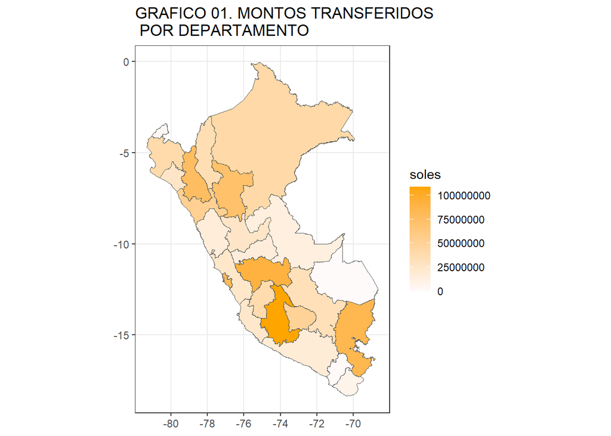

```r
library(ggplot2)
library(sf)


ggplot(df1, aes(geometry=geometry)) +
  geom_sf(aes(fill=Suma)) +
  theme_bw() +
  labs(fill = "soles") +
  labs(title = "GRAFICO 01. MONTOS TRANSFERIDOS \n POR DEPARTAMENTO") +
  scale_fill_gradient (low="snow", high="orange")
```

```r
#Anexo: Página de colores --> https://r-charts.com/es/colores/
```

A nivel provincia, destaca Lima Metropolitana con más de S/79 millones transferidos para la ejecución de proyectos de inversión, bastante más atrás se encuentran las provincias de Huamanga y Huancayo con casi S/32 millones y S/28 millones transferidos, respectivamente.

```r
library(mapsPERU)
df2 <- map_PROV
```

```r
TABLA2 <-bd_reactiva_pyto %>%
  group_by(COD_PROVINCIA) %>%
  summarise(suma=sum(MONTODETRANSFERENCIA2020))
```

```r
nuevafilas=data.frame(COD_PROVINCIA=c("010400", "010600", "020100", "020200", "020300", "020400", "020700", "020900", "021100", "021200", "021300", "021400", "021500", "021700", "022000", "030100", "030500", "040300", "040400", "040500", "040600", "040700", "040800", "050800", "061200", "080200", "080400", "080500", "080600", "081000", "081100", "081200", "081300", "100600", "100700", "100900", "101000", "110200", "110300", "110400", "120700", "120800", "130300", "130500", "130700", "130800", "140200", "150300", "150900", "160300", "160500", "160800", "170100", "170200", "170300", "180100", "180200", "190200", "200800", "210400", "220200", "230200", "230300", "230400", "240200", "250200", "250300", "250400"), suma=c(0, 0, 0, 0, 0, 0, 0, 0, 0, 0, 0, 0, 0, 0, 0, 0, 0, 0, 0, 0, 0, 0, 0, 0, 0, 0, 0, 0, 0, 0, 0, 0, 0, 0, 0, 0, 0, 0, 0, 0, 0, 0, 0, 0, 0, 0, 0, 0, 0, 0, 0, 0, 0, 0, 0, 0, 0, 0, 0, 0, 0, 0, 0, 0, 0, 0, 0, 0))

TABLA2=rbind(TABLA2,nuevafilas)
```

```r
# library(dplyr)
# library(sf)
df2 <- left_join(df2, TABLA2, by="COD_PROVINCIA")
str(TABLA2)
```

```
## tibble [196 × 2] (S3: tbl_df/tbl/data.frame)
##  $ COD_PROVINCIA: chr [1:196] "010100" "010200" "010300" "010500" ...
##  $ suma         : num [1:196] 4177586 16546325 5876360 3872595 4487606 ...
```

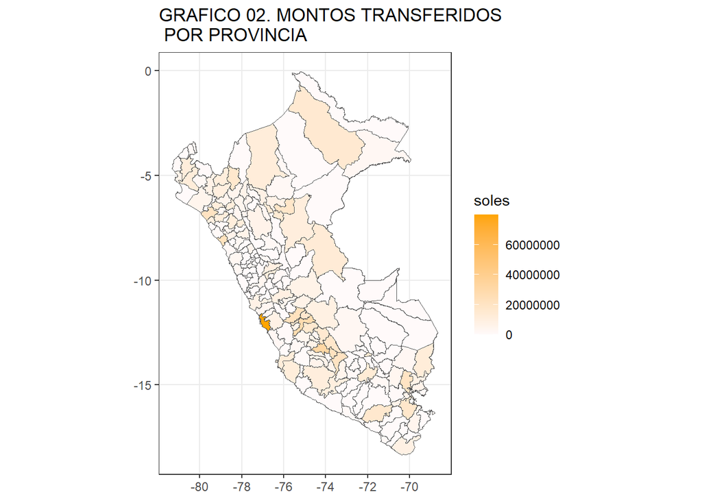

```r
# library(ggplot2)
ggplot(df2, aes(geometry=geometry)) +
  geom_sf(aes(fill=suma)) +
  theme_bw() +
  geom_sf(aes(fill=suma)) +
  labs(fill = "soles") +
  labs(title = "GRAFICO 02. MONTOS TRANSFERIDOS \n POR PROVINCIA") +
  scale_fill_gradient (low="snow", high="orange")
```